# AMMS COI Practical

Jason Hendry, Nick Brazeau

July 12, 2022

# Dependencies for Practical

Please copy and paste the below code chunk in it’s entirety to your console to download R package libraries needed for this practical. If you are having trouble installing any of the R packages, please ask an instructor for a pre-loaded flash drive.

```r
deps <- c("tidyverse", "vcfR", "McCOILR")
deps <- !sapply(deps, function(x){x %in% installed.packages()[,1]} )
if(any(deps)) {
  if(deps["McCOILR"]) {
    if (!"remotes" %in% installed.packages()[,1]){
      install.packages("remotes")
    }
    remotes::install_github("OJWatson/McCOILR")
    deps <- deps[names(deps) != "McCOILR"]
  } else {
    install.packages(names(deps)[deps])
  }
}
```

Please now load all of those libraries into this session using the code chunk below. Please copy and paste it in its entirety.

```r
library(tidyverse)
library(vcfR)
library(McCOILR)
```

Please set *your* working director so that you are in the `AMMS/COI` directory. If you are having trouble finding that path, you can use the `file.choose` function to help determine its location.

# Practical Goals

# 1 Importing Data

```r
DRCongo <- vcfR::read.vcfR("data/SNPs.DRCongo.setA.random96.vcf")
```

[output not shown]

```r
#Vietnam <- vcfR::read.vcfR("data/SNPs.Vietnam.setD.random96.vcf")
```

## 1.1 Munging & Extracting Genomic Data for DRC

- going to go from wide to long for ease

```r
# extract information
# loci <- vcfR::extract_info_tidy(DRCongo)
#TODO Jason *** - above throws an error, it shouldn't unless vcf is misbehaving. haven't dug in. longer approach below

loci <- DRCongo@fix[,1:2] %>%
  tibble::as_tibble() %>%
  dplyr::mutate(POS = as.numeric(POS),
                Key = 1:dplyr::n()) %>%
  dplyr::select(c("CHROM", "POS", "Key"))


# extract GT information and get WSRAF for every sample at each loci
DRCongo_long <- DRCongo %>%
  vcfR::extract_gt_tidy() %>%
  # lets make some new variables
  dplyr::mutate(
    # need to change the GT character to a numeric for maths
    gt = dplyr::case_when(gt_GT == "0/0" ~ 0,
                          gt_GT == "0/1" ~ 0.5,
                          gt_GT == "1/1" ~ 1),
    # get reference allele depth
    rad = purrr::map_dbl(gt_AD, function(x){vcfR::masplit(
      as.matrix(x), record = 1, sort = FALSE, decreasing = FALSE)}),
    # get alternate allele depth
    aad = purrr::map_dbl(gt_AD, function(x){vcfR::masplit(
      as.matrix(x), record = 2, sort = FALSE, decreasing = FALSE)}),
    # calculate within-sample reference allele freq
    wsraf = rad/(rad + aad),
    wsraf = ifelse(is.nan(wsraf), NA, wsraf) # occurs when 0/0
    ) %>%
  # now let's select the variables that we want
  dplyr::select(c("Key", "Indiv", "gt", "wsraf")) %>%
  # now lets combine the loci information with the individual level information
  dplyr::full_join(x = loci, y = ., by  = "Key") %>%
  # don't need Key anymore
  dplyr::select(-c("Key"))
```

### 1.1.1 Look at VCF in “long” format

```r
head(DRCongo_long)
```

```
## # A tibble: 6 × 5
##   CHROM          POS Indiv       gt wsraf
##   <chr>        <dbl> <chr>    <dbl> <dbl>
## 1 Pf3D7_01_v3 180554 QG0182-C     1     0
## 2 Pf3D7_01_v3 180554 QG0183-C     0     1
## 3 Pf3D7_01_v3 180554 QG0184-C     1     0
## 4 Pf3D7_01_v3 180554 QG0185-C     0     1
## 5 Pf3D7_01_v3 180554 QG0186-C     0     1
## 6 Pf3D7_01_v3 180554 QG0187-C     0     1
```

# 2 Population Level Allele Frequencies

```r
DRC_plaf <- DRCongo_long %>%
  dplyr::group_by(CHROM, POS) %>%
  dplyr::summarise(
    # multiple by 2 to assume diploid genome
    PLAF = sum(gt * 2, na.rm = T) / (2* sum(!is.na(gt)))
  )
```

### 2.0.1 Visualizing PLAF

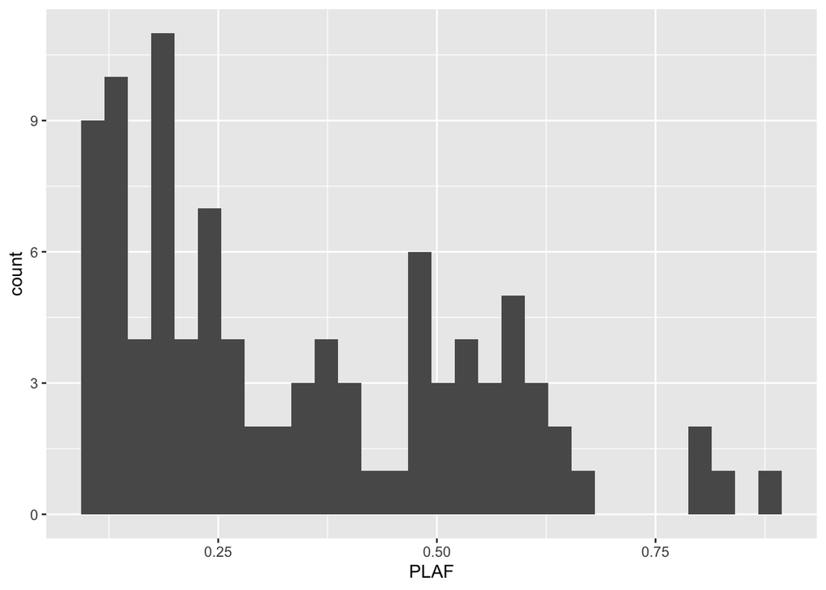

```r
DRC_plaf %>%
  ggplot() +
  geom_histogram(aes(x = PLAF))
```

# 3 Calculating COI

## 3.1 Reformatting data for RMCL

```r
# wide format
DRCongo_RMCL <- DRCongo_long %>%
  dplyr::mutate(loci = paste(CHROM, POS, sep = "|")) %>%
  dplyr::select(c("loci", "Indiv", "gt")) %>%
  # liftover missing for RMCL
  dplyr::mutate(gt = ifelse(is.na(gt), -1, gt)) %>%
  tidyr::pivot_wider(names_from = "Indiv",
                     values_from = "gt")
# make matrix and format for RMCL
DRCongo_RMCLmat <- as.matrix(DRCongo_RMCL[2:ncol(as.matrix(DRCongo_RMCL))])
rownames(DRCongo_RMCLmat) <- DRCongo_RMCL[["loci"]]
DRCongo_RMCLmat <- t(DRCongo_RMCLmat)
# make list of multiple SNP sets
gts_rmcl <- list("DRCsetA" = DRCongo_RMCLmat)
```

## 3.2 Running RMCL

Do this into the /COI directory `git clone https://github.com/EPPIcenter/THEREALMcCOIL.git` Also see: https://github.com/EPPIcenter/THEREALMcCOIL/tree/master/categorical_method

```r
# Prepare output directory
output_dir <- "results"
if (!dir.exists(output_dir)) {
  dir.create(output_dir)
}
out_cat <- McCOIL_categorical(gts_rmcl[["DRCsetA"]],
                              maxCOI=25, threshold_ind=20,
                              threshold_site=20,
                              totalrun=1000, burnin=100, M0=15,
                              e1=0.05, e2=0.05,
                              err_method=3,
                              path="results",
                              output="output_DRCsetA.txt" )
```

```
## Time = 3.00 s
```

## 3.3 Exploring THEREALMcCOIL outputs

```r
# Load summary data
DRCongo_COI <- readr::read_table("results/output_DRCsetA.txt_summary.txt") %>%
  # Subset to COI results
  dplyr::filter(CorP == "C") %>%
  # select to rows we care about
  dplyr::select(-c("file", "CorP")) %>%
  dplyr::rename(Indiv = name)

# Compute fraction mixed
DRCongo_COI %>%
  dplyr::summarise(frac_mixed = sum(mean > 1) / dplyr::n())
```

```
## # A tibble: 1 × 1
##   frac_mixed
##        <dbl>
## 1      0.982
```

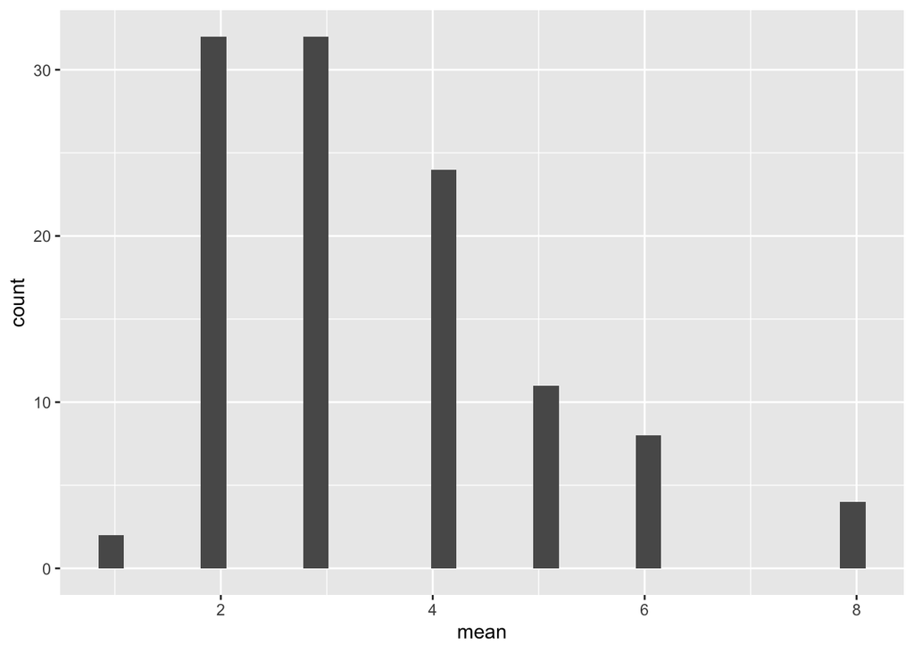

```r
# What does the distribution look like?
DRCongo_COI %>%
  ggplot() +
  geom_histogram(aes(x = mean))
```

## TODO think of more exploration

# 4 Heterozygosityand Fws

## 4.1 Exploring WSAF

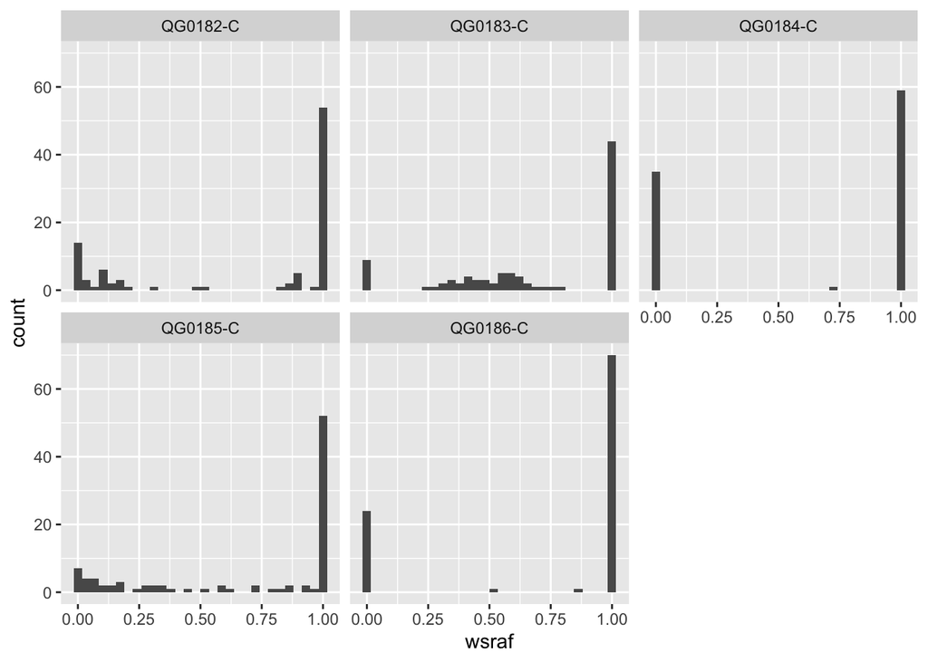

```r
# pick five individuals
fivefriends <- DRCongo_long$Indiv[1:5]
DRCongo_long %>%
  dplyr::filter(Indiv %in% fivefriends) %>%
  ggplot() +
  geom_histogram(aes(x = wsraf)) +
  facet_wrap(~Indiv)
```

### TODO - have participants explore wsraf vs COI call?

### 4.1.1 Comparing PLAF vs mean WSAFs

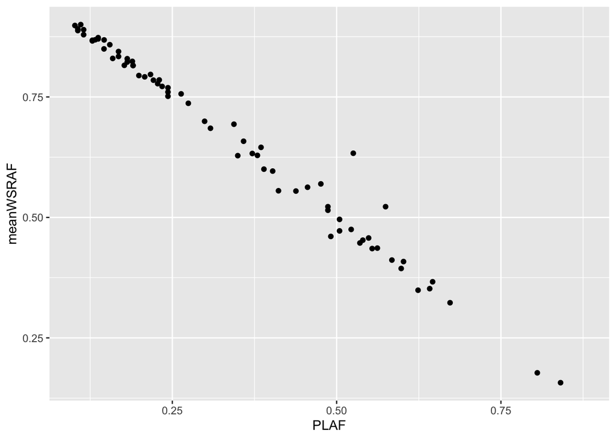

```r
DRCongo_long %>%
  dplyr::group_by(CHROM, POS) %>%
  dplyr::summarise(meanWSRAF = mean(wsraf, rm.na = T)) %>%
  dplyr::full_join(DRC_plaf, ., by = c("CHROM", "POS")) %>%
  ggplot() +
  geom_point(aes(x = PLAF, y = meanWSRAF))
```

### 4.1.2 Compute heterozygosities

```r
calc_biallelic_heterozygosity <- function(p_alt) {
  return (p_alt * (1 - p_alt))
}

# calculate het for samples
DRCongo_long <- DRCongo_long %>%
  dplyr::mutate(
    het_wsafs = purrr::map_dbl(wsraf, calc_biallelic_heterozygosity)
  )

# calculate het for pop
DRC_plaf <- DRC_plaf %>%
  dplyr::mutate(
    het_plaf = purrr::map_dbl(PLAF, calc_biallelic_heterozygosity)
  )

# now calculate fws
DRCongo_fws <- dplyr::full_join(DRCongo_long, DRC_plaf, by = "CHROM", "POS") %>%
  dplyr::group_by(Indiv) %>%
  dplyr::summarise(
    fws = mean( 1 - het_wsafs / het_plaf, na.rm = T)
  )
```

### 4.1.3 Visualize Heterozygosity

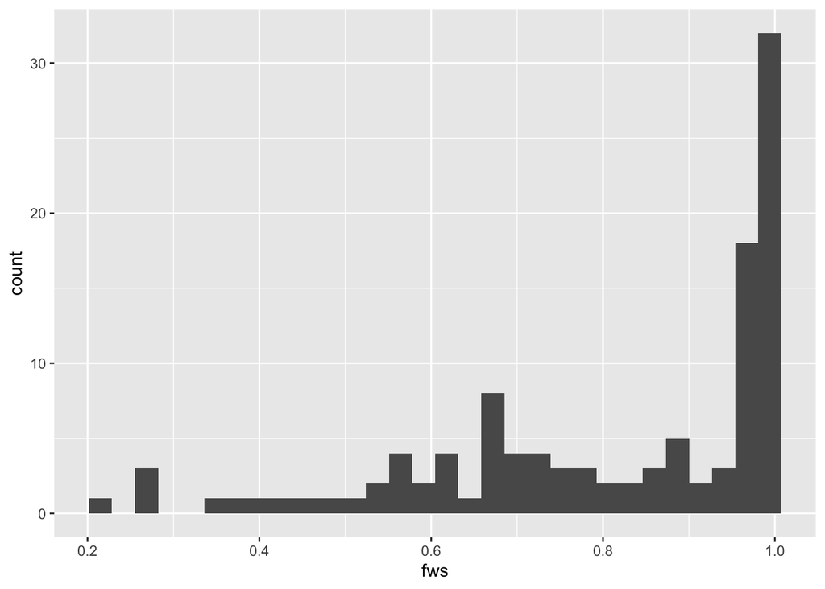

```r
DRCongo_fws %>%
  ggplot() +
  geom_histogram(aes(x = fws))
```

# 5 COI vs Heterozygosity Relationships

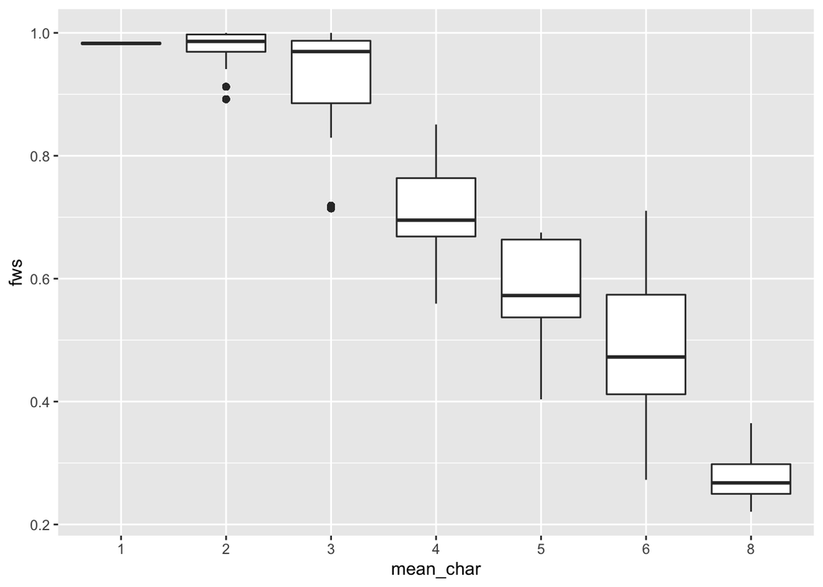

```r
# now combine for a final dataframe
DRCongo_final <- DRCongo_long %>%
  dplyr::left_join(., DRCongo_COI, by = "Indiv") %>%
  dplyr::left_join(., DRCongo_fws, by = "Indiv")

# plot
DRCongo_final %>%
  dplyr::mutate(mean_char = as.factor(mean)) %>%
  ggplot() +
  geom_boxplot(aes(x = mean_char, y = fws))
```

#### TODO more relationships